# Pre-process Biomass Data

Mary Fisher

February 28, 2020

We found minimal correlation between giant kelp size and abundance, and the fish and invertebrate metrics of abundance / richness / diversity. This finding is contrary to existing scientific research and knowledge of kelp forest ecosystems, and may have been a function of they way that I cleaned and summarized the SBC LTER data sets. I’m going to look at the biomass data provided by the SBC LTER, which has been summarized at the transect (replicate / site) level. My hope is that scientists with the SBC LTER, who have a more extensive understanding of this data set, may have cleaned and summarized their survey data using a different - and more appropriate - approach than I did.

Biomass is a measure of the mass of a given biological community. It can be used in place of raw count data to represent abundance, diversity, and community composition.

## Raw Data

*SBCLTER Abstract*: These data are annual estimates of biomass of approximately 225 taxa of reef algae, invertebrates and fish in permanent transects at 11 kelp forest sites in the Santa Barbara Channel (2-8 transects per site). Abundance is measured annually (as percent cover or density, by size) and converted to biomass (i.e., wet mass, dry mass, decalcified dry mass, ash free dry mass) using published taxon-specific algorithms. Data collection began in summer 2000 and continues annually in summer to provide information on community structure, population dynamics and species change. The time period of data collection varied among the 11 kelp forest sites. Sampling at BULL, CARP, and NAPL began in 2000, sampling at the other 6 mainland sites (AHND, AQUE, IVEE, GOLB, ABUR, MOHK) began in 2001 (transects 3, 5, 6, 7, 8 at IVEE were added in 2011). Data collection at the two Santa Cruz Island sites (SCTW and SCDI) began in 2004. See Methods for more information. See Methods for more information.

```
## [1] 178812     24
```

```
##  [1] "year"            "month"           "date"            "site"
##  [5] "transect"        "sp_code"         "percent_cover"   "density"
##  [9] "wm_gm2"          "dry_gm2"         "sfdm"            "afdm"
## [13] "scientific_name" "common_name"     "taxon_kingdom"   "taxon_phylum"
## [17] "taxon_class"     "taxon_order"     "taxon_family"    "taxon_genus"
## [21] "group"           "mobility"        "growth_morph"    "coarse_grouping"
```

How much missing data is there across the different biomass calculations per group?

```
## # A tibble: 3 x 5
##   group     wm   dry    sf   ash
##   <fct>  <dbl> <dbl> <dbl> <dbl>
## 1 ALGAE  1.000 1.000 1.000 1.000
## 2 FISH   0.989 0.989 0     0.882
## 3 INVERT 1.000 1.000 1.000 1.000
```

Wet mass and dry mass calculations have the least missing data. I’ll stick with the dry mass calculations for now.

## Transect-level Biomass

### Process data

Total and mean biomass per group / site / transect.

```
## # A tibble: 6 x 12
## # Groups:   year, month, site, transect [15]
##    year month site  transect fish_total_biom~ fish_mean_bioma~ invert_total_bi~
##   <int> <int> <fct>    <int>            <dbl>            <dbl>            <dbl>
## 1  2000     9 BULL         1            4.46            0.0797            1943.
## 2  2000     9 BULL         3           10.7             0.191             1259.
## 3  2000     9 BULL         6            0.768           0.0137            2614.
## 4  2000     9 CARP         1            2.00            0.0357            1801.
## 5  2000     9 CARP         2            0               0                 4664.
## 6  2000     9 CARP         3            1.92            0.0342            3377.
## # ... with 5 more variables: invert_mean_biomass <dbl>,
## #   algae_total_biomass <dbl>, algae_mean_biomass <dbl>,
## #   kelp_total_biomass <dbl>, kelp_mean_biomass <dbl>
```

### Relationship between Variables

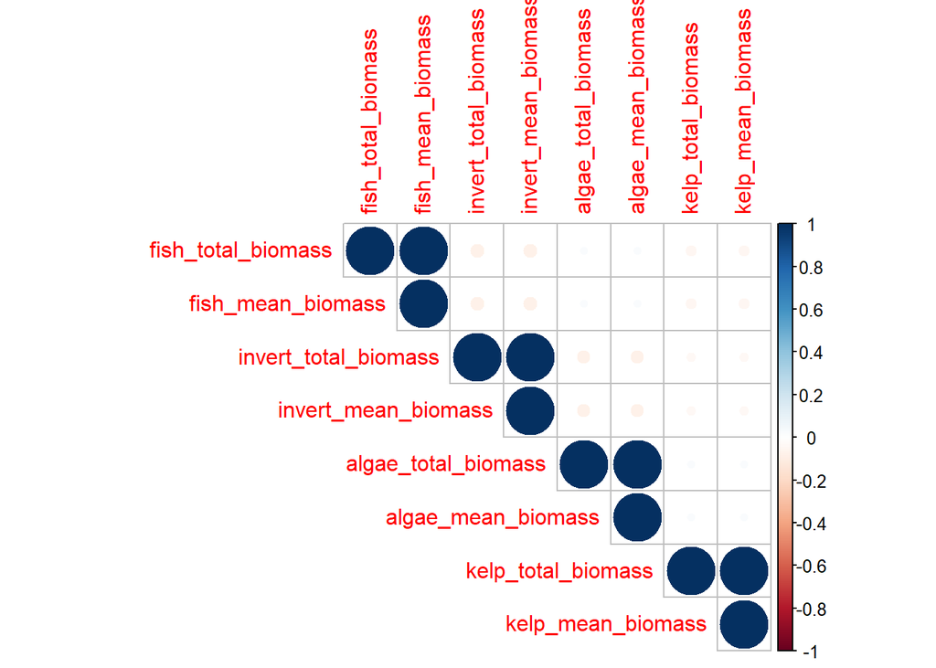

Fish & Kelp

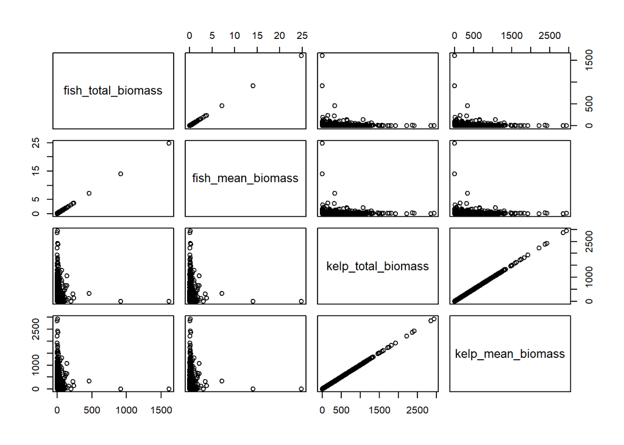

Invertebrates & Kelp

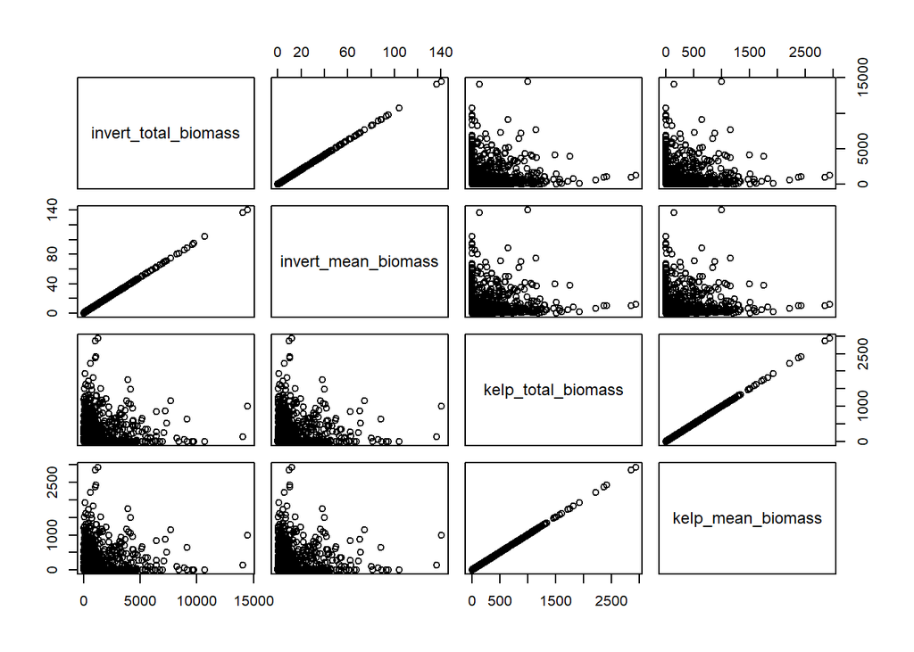

Algae & Kelp

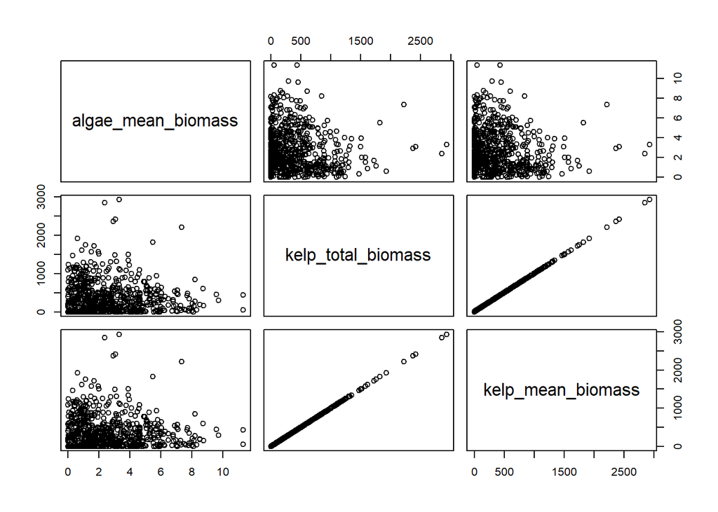

Fish & Invertebrates

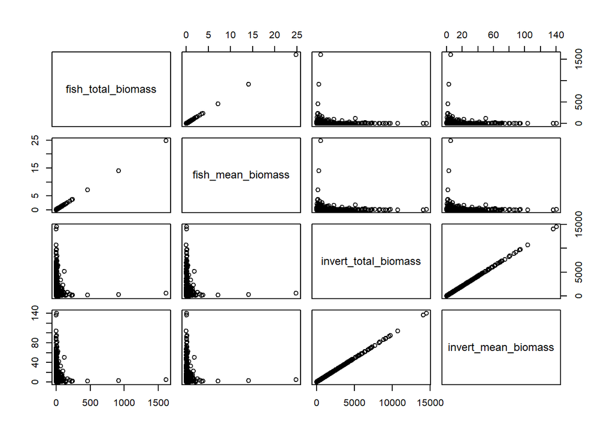

## Site-level Biomass

### Process Data

What if we look at the site level, instead of at the level of transects? This would account for spatial heterogeneity in kelp, fish and invertebrate biomass across transects, assuming that it is the site-level biomass that actually matters.

```
## # A tibble: 6 x 11
## # Groups:   year, month, site [22]
##    year month site  fish_total_biom~ fish_mean_bioma~ invert_total_bi~
##   <int> <int> <fct>            <dbl>            <dbl>            <dbl>
## 1  2000     9 BULL             15.9            0.0948           5815.
## 2  2000     9 CARP             11.9            0.0266          18481.
## 3  2000     9 NAPL            121.             0.269            6004.
## 4  2001     8 ABUR              4.66           0.0358             24.9
## 5  2001     8 AHND             20.5            0.158              70.4
## 6  2001     8 AQUE            113.             0.349            7932.
## # ... with 5 more variables: invert_mean_biomass <dbl>,
## #   algae_total_biomass <dbl>, algae_mean_biomass <dbl>,
## #   kelp_total_biomass <dbl>, kelp_mean_biomass <dbl>
```

I’ll also calculate the Simpson diversity index using biomass.

```
## # A tibble: 6 x 14
## # Groups:   year, month, site [22]
##    year month site  fish_total_biom~ fish_mean_bioma~ invert_total_bi~
##   <int> <int> <fct>            <dbl>            <dbl>            <dbl>
## 1  2000     9 BULL             15.9            0.0948           5815.
## 2  2000     9 CARP             11.9            0.0266          18481.
## 3  2000     9 NAPL            121.             0.269            6004.
## 4  2001     8 ABUR              4.66           0.0358             24.9
## 5  2001     8 AHND             20.5            0.158              70.4
## 6  2001     8 AQUE            113.             0.349            7932.
## # ... with 8 more variables: invert_mean_biomass <dbl>,
## #   algae_total_biomass <dbl>, algae_mean_biomass <dbl>,
## #   kelp_total_biomass <dbl>, kelp_mean_biomass <dbl>, fish_diversity <dbl>,
## #   invert_diversity <dbl>, algae_diversity <dbl>
```

### Relationship between variables

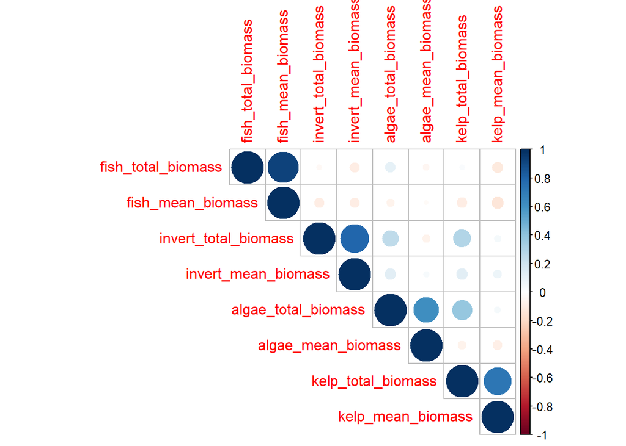

There seem to be some relationships between invertebrate - algae biomass, and algae - kelp biomass.

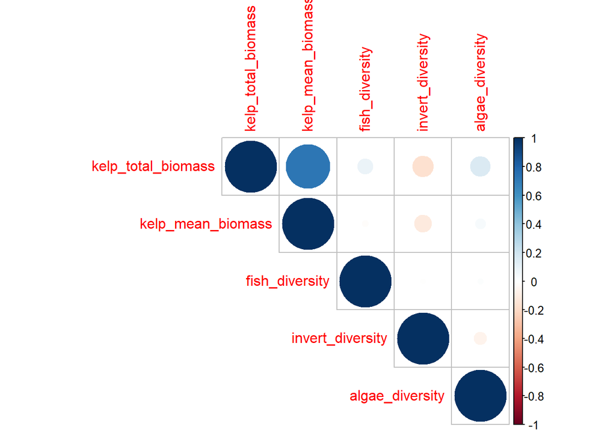

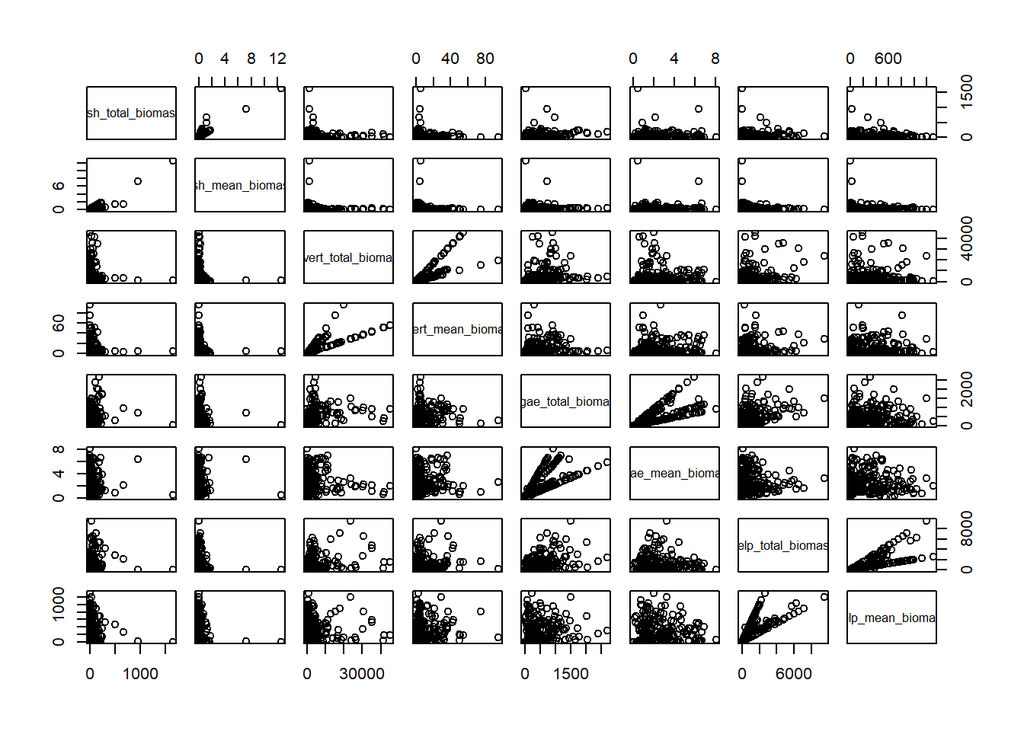

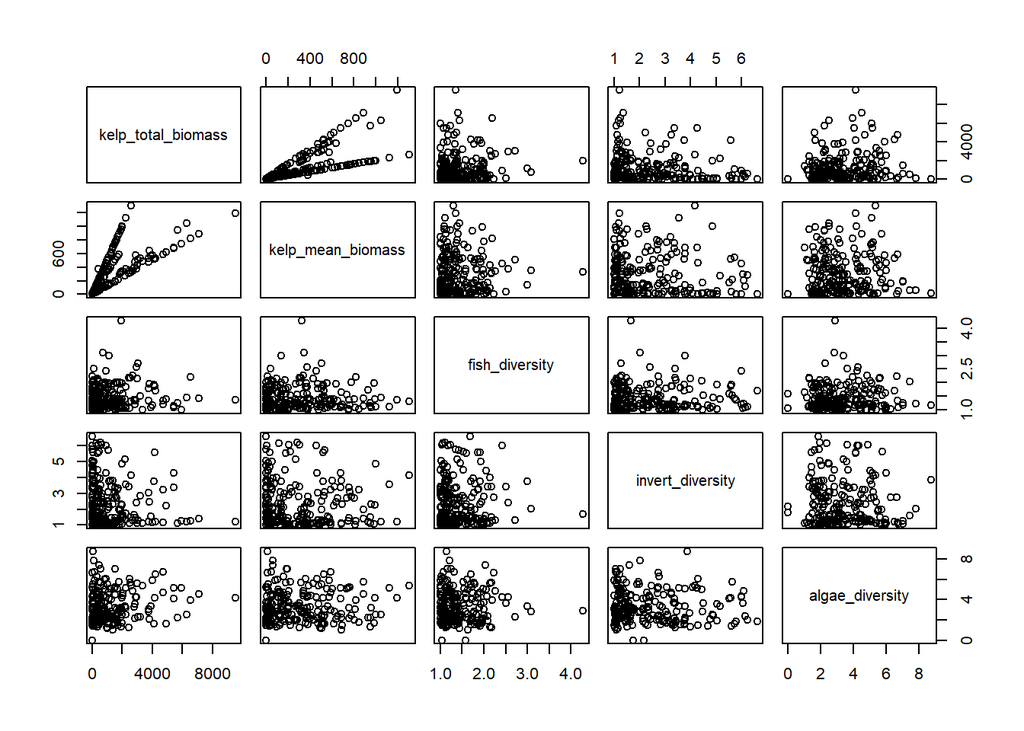

### Write out

First, all of the biomass metrics at the site-level.

```
##  [1] "year"                 "month"                "site"
##  [4] "fish_total_biomass"   "fish_mean_biomass"    "invert_total_biomass"
##  [7] "invert_mean_biomass"  "algae_total_biomass"  "algae_mean_biomass"
## [10] "kelp_total_biomass"   "kelp_mean_biomass"    "fish_diversity"
## [13] "invert_diversity"     "algae_diversity"
```

```
##  [1] "year"                 "month"                "site"
##  [4] "fish_total_biomass"   "fish_diversity"       "invert_total_biomass"
##  [7] "invert_diversity"     "algae_total_biomass"  "algae_diversity"
## [10] "kelp_total_biomass"
```

Finally, read in the water chemistry variables and include that in the data set.

```
##  [1] "year"                 "month"                "site"
##  [4] "fish_total_biomass"   "fish_diversity"       "invert_total_biomass"
##  [7] "invert_diversity"     "algae_total_biomass"  "algae_diversity"
## [10] "kelp_total_biomass"   "summer_mean_temp"     "summer_var_temp"
## [13] "winter_mean_temp"     "winter_var_temp"      "max_ammonia"
## [16] "max_no2_no3"          "max_po4"              "max_poc"
## [19] "max_pon"              "max_tchl"             "mean_ammonia"
## [22] "mean_no2_no3"         "mean_po4"             "mean_poc"
## [25] "mean_pon"             "mean_tchl"
```